# Chapter06. 변수변환

Jeong-Eun Lee

2021 7 3

### 6.1 소개

- 변수변환의 목적 : 선형성, 정규성, 분산의 안정화 등을 달성하기 위하여 실행 -> 표준적인 회귀의 가정 충족하도록 함
- 분산 안정화변환 : 오차항이 등분산성을 가지도록 함

### 6.2 선형성을 위한 변환들

- 선형화 할 수 없는 단순한 비선형모형 : 수정지수곡선, 두 지수함수의 선형합 등

### 6.3 X-선 방사에 의한 박테리아 사망률

```r
x_bac = read.table("C:\\Users\\X-Note\\Desktop\\x-bac.txt", header = T)
head(x_bac)
```

```
##   t N_t
## 1 1 355
## 2 2 211
## 3 3 197
## 4 4 166
## 5 5 142
## 6 6 106
```

- 변수 : $n_t$ = 생존하는 박테리아의 수(100마리 단위), $t$ = 노출시간
- 이론 : 각 박테리아에는 하나의 생명중심체가 있고 이것이 X-선에 맞았을 때 그 박테리아는 죽게 되며, 생존한 박테리아 수의 로그값은 노출시간에 대해 직선적인 관계를 가진다.
- 시간($t$)에 따라 생존하는 박테리아 수($n_t$)의 관계식 : $n_t = n_0e^{\beta_1t}, t>0$
  - 여기에서 모수 $n_0$는 실험을 시작할 시점($t = 0$)에서의 박테리아 수이고, $\beta_1$은 감소율을 의미함.
- 위의 식을 로그변환하면
  $$ln\,n_t = ln\,n_0 + \beta_1t = \beta_0 + \beta_1t$$
  $$ln\,n_t = \beta_0 + \beta_1t + \epsilon_t$$

#### 6.3.1 선형모형의 부적절성

- 단계 1) 원래 데이터에 대해 $n_t$ 대 $t$의 플롯 그리기 -> 시간($t$) 값이 큰 경우 선형성에서 상당히 벗어남 + 특이값 존재

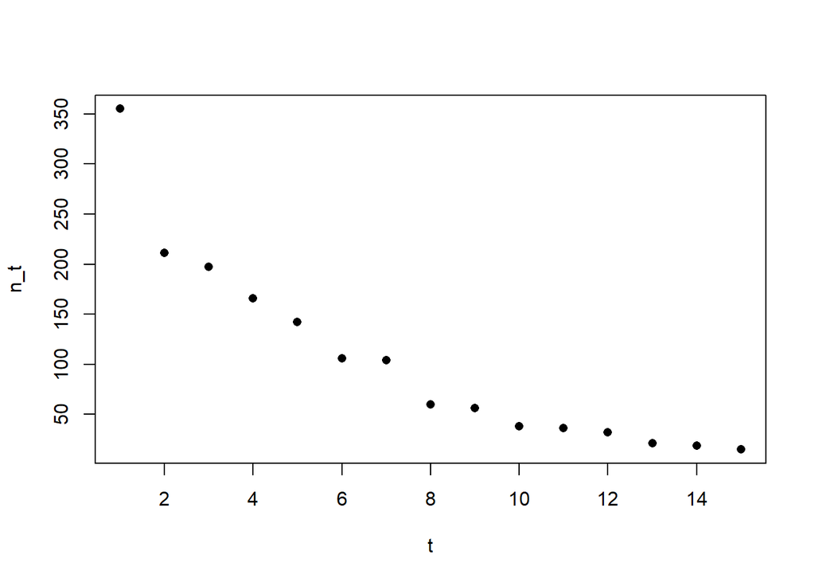

```r
plot(x_bac$t, x_bac$N_t, xlab = "t", ylab = "n_t", pch = 16)
```

- 단계 2) 원래 데이터에 대해 회귀적합 -> 회귀계수 유의, $R^2$값 높음(-> 유의하지 않는 이유)

```r
fit1 = lm(N_t ~ t, data = x_bac)
summary(fit1)
```

```
##
## Call:
## lm(formula = N_t ~ t, data = x_bac)
##
## Residuals:
##     Min      1Q  Median      3Q     Max
## -43.867 -23.599  -9.652  10.223 114.883
##
## Coefficients:
##             Estimate Std. Error t value Pr(>|t|)
## (Intercept)   259.58      22.73  11.420 3.78e-08 ***
## t             -19.46       2.50  -7.786 3.01e-06 ***
## ---
## Signif. codes:  0 '***' 0.001 '**' 0.01 '*' 0.05 '.' 0.1 ' ' 1
##
## Residual standard error: 41.83 on 13 degrees of freedom
## Multiple R-squared:  0.8234, Adjusted R-squared:  0.8098
## F-statistic: 60.62 on 1 and 13 DF,  p-value: 3.006e-06
```

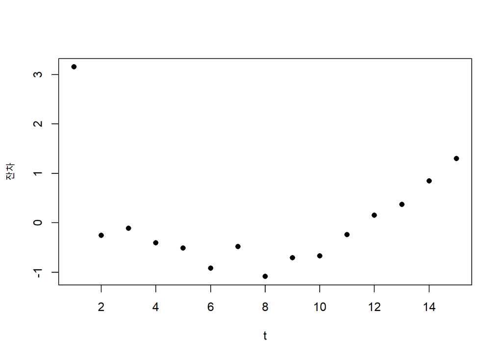

```r
plot(rstandard(fit1), xlab = "t", ylab = "잔차", pch = 16)
```

#### 6.3.2) 선형성을 위한 로그변환

- 단계 3) $n_t$에 로그변환한 데이터에 대해 $ln\,n_t$ 대 $t$의 플롯 그리기 -> 선형성을 띰

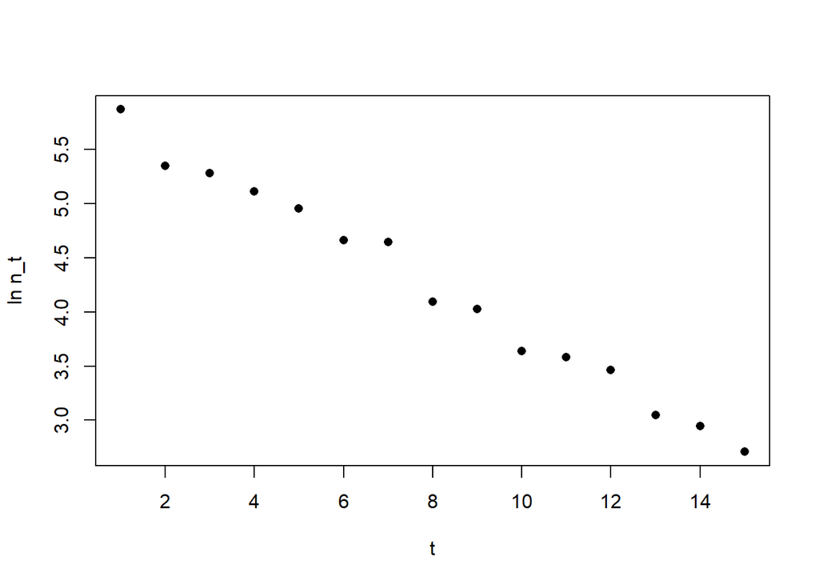

```r
plot(x_bac$t, log(x_bac$N_t),  xlab = "t", ylab = "ln n_t", pch = 16)
```

- 단계 4) $n_t$에 로그변환한 데이터에 대해 회귀적합 -> 회귀계수 모두 유의, 표준오차 감소, $R^2 \approx 0.99$

```r
fit2 = lm(log(N_t) ~ t, data = x_bac)
summary(fit2)
```

```
##
## Call:
## lm(formula = log(N_t) ~ t, data = x_bac)
##
## Residuals:
##      Min       1Q   Median       3Q      Max
## -0.18445 -0.06189  0.01253  0.05201  0.20021
##
## Coefficients:
##              Estimate Std. Error t value Pr(>|t|)
## (Intercept)  5.973160   0.059778   99.92  < 2e-16 ***
## t           -0.218425   0.006575  -33.22 5.86e-14 ***
## ---
## Signif. codes:  0 '***' 0.001 '**' 0.01 '*' 0.05 '.' 0.1 ' ' 1
##
## Residual standard error: 0.11 on 13 degrees of freedom
## Multiple R-squared:  0.9884, Adjusted R-squared:  0.9875
## F-statistic:  1104 on 1 and 13 DF,  p-value: 5.86e-14
```

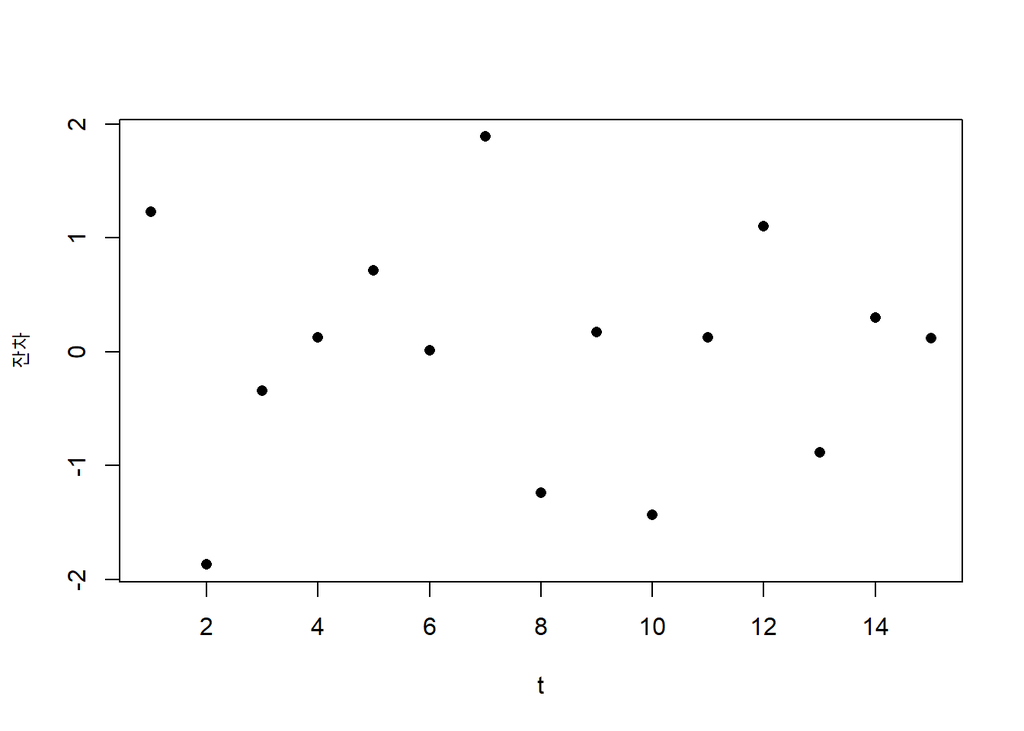

```r
plot(rstandard(fit2), xlab = "t", ylab = "잔차", pch = 16)
```

- $\beta_1$의 최소제곱추정치 = -0.218
- $\beta_1$의 신뢰구간 : (-0.218 - 1.96 * 0.0066, -0.218 + 1.96 * 0.0066) = (-0.231, -0.205)
- $\beta_1$은 $\beta_0$의 최량선형불편추정량(BLUE)
  - 최량선형불편추정량 : 최소제곱추정량들은 반응변수에 대한 관찰값들의 선형결합 꼴로 표현할 수 있는 모든 가능한 불편추정량들 중에서 최소분산을 가지는 경우

### 6.4 분산안정화 변환

- 변수변환의 목적 : 오차항의 분산을 안정시켜 등분산성을 유지하는 것
- 이분산성 : 오차항의 분산이 모든 관측값에 대하여 똑같은 상수항을 취하지 않을 경우 -> 이론적 타당성 x, 정확성 신뢰 x
  - ex) 잔차들의 변이가 X값에 따라서 점점 커지거나 작아지는 깔때기 형태의 분포를 가짐
- 분산 안정화를 위한 변환들 : 포아송분포($\sqrt(Y)$), 이항분포($sin^{-1}(\sqrt(Y))$), 음이항($\lambda^{-1}sinh^{-1}(\lambda\sqrt(Y)$)

### 6.5 이분산성의 검출

- 27개 제조회사의 종업원과 감독자의 수의 관계를 알아본다.

```r
factory = read.table("C:\\Users\\X-Note\\Desktop\\factory.txt", header = T)
head(factory)
```

```
##     X  Y
## 1 294 30
## 2 247 32
## 3 267 37
## 4 358 44
## 5 423 47
## 6 311 49
```

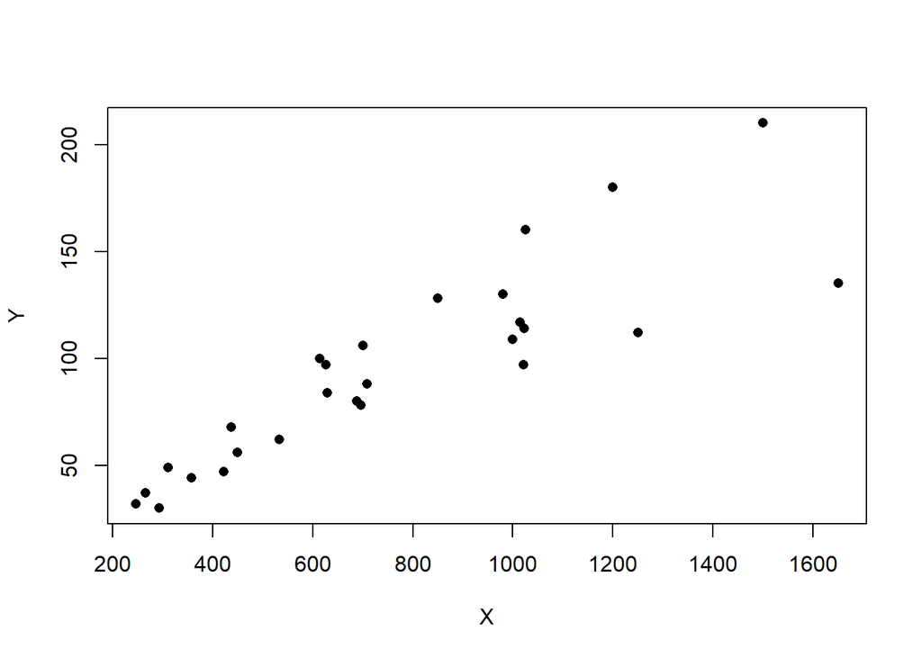

```r
plot(factory$X, factory$Y, xlab = "X", ylab = "Y", pch = 16)
```

```r
fit3 = lm(Y ~ X, data = factory)
summary(fit3)
```

```
##
## Call:
## lm(formula = Y ~ X, data = factory)
##
## Residuals:
##     Min      1Q  Median      3Q     Max
## -53.294  -9.298  -5.579  14.394  39.119
##
## Coefficients:
##             Estimate Std. Error t value Pr(>|t|)
## (Intercept) 14.44806    9.56201   1.511    0.143
## X            0.10536    0.01133   9.303 1.35e-09 ***
## ---
## Signif. codes:  0 '***' 0.001 '**' 0.01 '*' 0.05 '.' 0.1 ' ' 1
##
## Residual standard error: 21.73 on 25 degrees of freedom
## Multiple R-squared:  0.7759, Adjusted R-squared:  0.7669
## F-statistic: 86.54 on 1 and 25 DF,  p-value: 1.35e-09
```

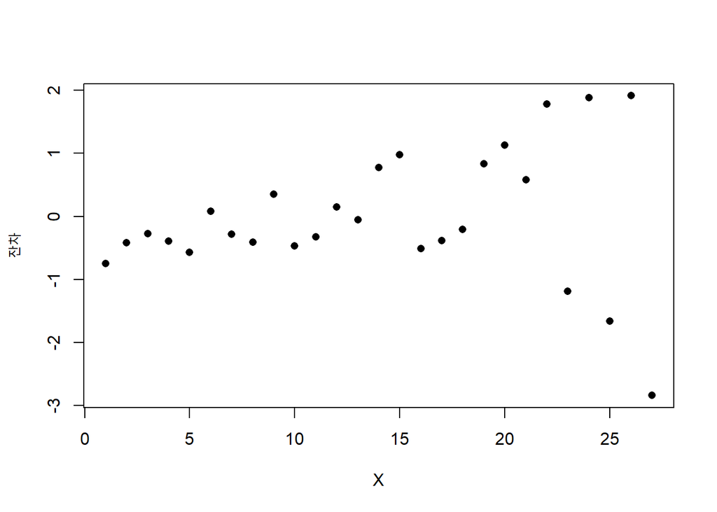

```r
plot(rstandard(fit3), xlab = "X", ylab = "잔차", pch = 16)
```

- X에 대한 표준화잔차플롯을 보면, X의 값이 증가함에 따라 표준화잔차들은 그 폭이 점차 커지는 띠 안에 포함되는 것으로 나타난다.
- 표준화잔차플롯의 해석방법
  1. x의 증가에 따라 잔차들을 포함한 띠가 넓어지면 : x에 따라 오차항의 분산도 증가한다.
  2. x의 증가에 따라 잔차들을 포함한 띠가 좁아지면 : x에 따라 오차항의 분산도 감소한다.
  3. x의 증가에 따라 잔차들을 포함한 띠가 x축과 평행이면 : 이분산성에 대한 증거가 없다. -> 등분산 충족 -> 최소제곱추정에 대한 기본 가정이 만족

### 6.6 이분산성의 제거

```r
Y_1 = factory$Y/factory$X
X_1 = 1/factory$X
fit4 = lm(Y_1 ~ X_1, data = factory)
summary(fit4)
```

```
##
## Call:
## lm(formula = Y_1 ~ X_1, data = factory)
##
## Residuals:
##       Min        1Q    Median        3Q       Max
## -0.041477 -0.013852 -0.004998  0.024671  0.035427
##
## Coefficients:
##             Estimate Std. Error t value Pr(>|t|)
## (Intercept) 0.120990   0.008999  13.445 6.04e-13 ***
## X_1         3.803296   4.569745   0.832    0.413
## ---
## Signif. codes:  0 '***' 0.001 '**' 0.01 '*' 0.05 '.' 0.1 ' ' 1
##
## Residual standard error: 0.02266 on 25 degrees of freedom
## Multiple R-squared:  0.02696,    Adjusted R-squared:  -0.01196
## F-statistic: 0.6927 on 1 and 25 DF,  p-value: 0.4131
```

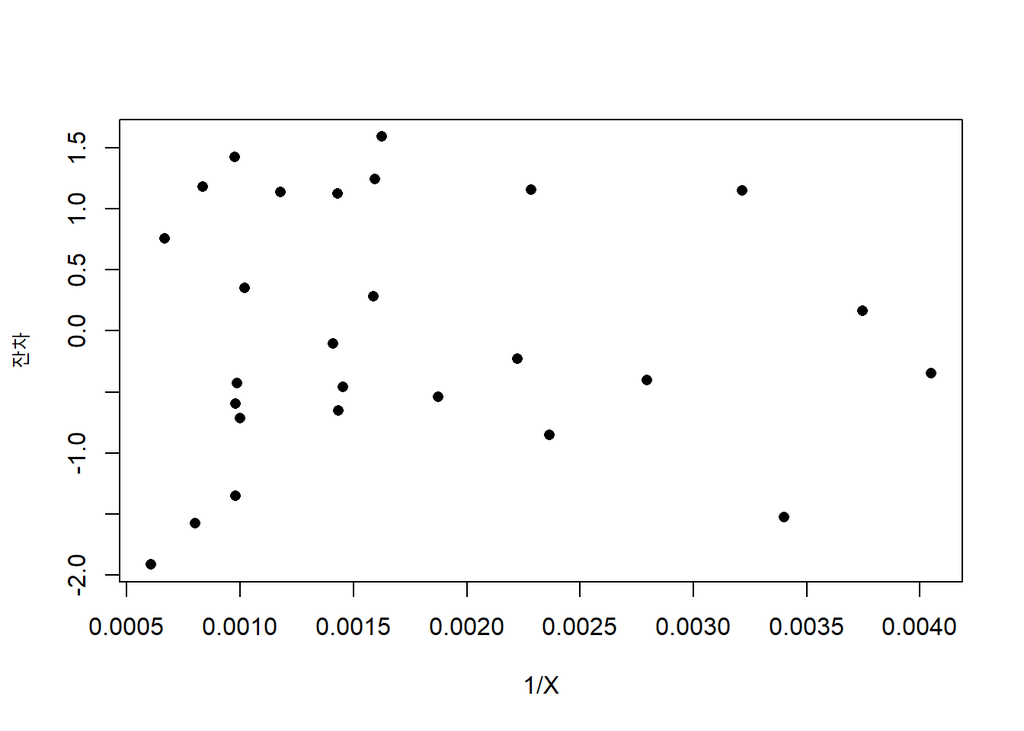

```r
plot(X_1, rstandard(fit4), xlab = "1/X", ylab = "잔차", pch = 16)
```

- 원모형 $\hat{Y} = \hat{\beta_1'} + \hat{\beta_0'}X$를 변환모형 $y_i' = \beta_0' + \beta_1'x_i + \epsilon_i'$의 형태로 바꾸어 회귀 적합을 하니 표준화잔차플롯에서 이분산성에 대한 특별한 단서를 발견할 수 없어 즉 변환된 모형은 등분산성을 충족한다고 할 수 있다.
- 표준화잔차플롯 출력 시 A에 대한 B의 회귀로부터의 조건에 대해서는 “plot(A, rstandard(fitB), ~ )”로 작성해야 인덱스가 아닌 A에 대한 플롯이 그려짐

### 6.4.+ 항공사 사상사고 데이터

- 변수 : $Y$ - 사상사고 발생건수, $N$ - 항공편 운항률

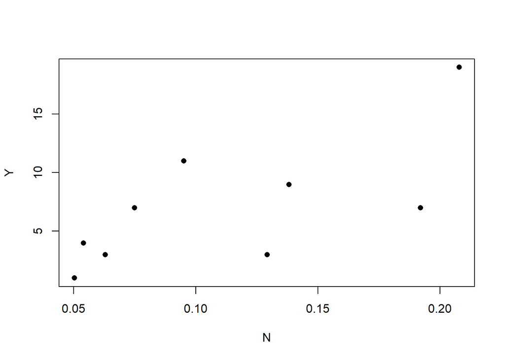

```r
flight = read.table("C:\\Users\\X-Note\\Desktop\\flight.txt", header = T)
plot(flight$N, flight$Y, xlab = "N", ylab = "Y", pch = 16)
```

```r
fit5 = lm(Y ~ N, data = flight)
summary(fit5)
```

```
##
## Call:
## lm(formula = Y ~ N, data = flight)
##
## Residuals:
##     Min      1Q  Median      3Q     Max
## -5.3351 -2.1281  0.1605  2.2670  5.6382
##
## Coefficients:
##             Estimate Std. Error t value Pr(>|t|)
## (Intercept)  -0.1402     3.1412  -0.045   0.9657
## N            64.9755    25.1959   2.579   0.0365 *
## ---
## Signif. codes:  0 '***' 0.001 '**' 0.01 '*' 0.05 '.' 0.1 ' ' 1
##
## Residual standard error: 4.201 on 7 degrees of freedom
## Multiple R-squared:  0.4872, Adjusted R-squared:  0.4139
## F-statistic:  6.65 on 1 and 7 DF,  p-value: 0.03654
```

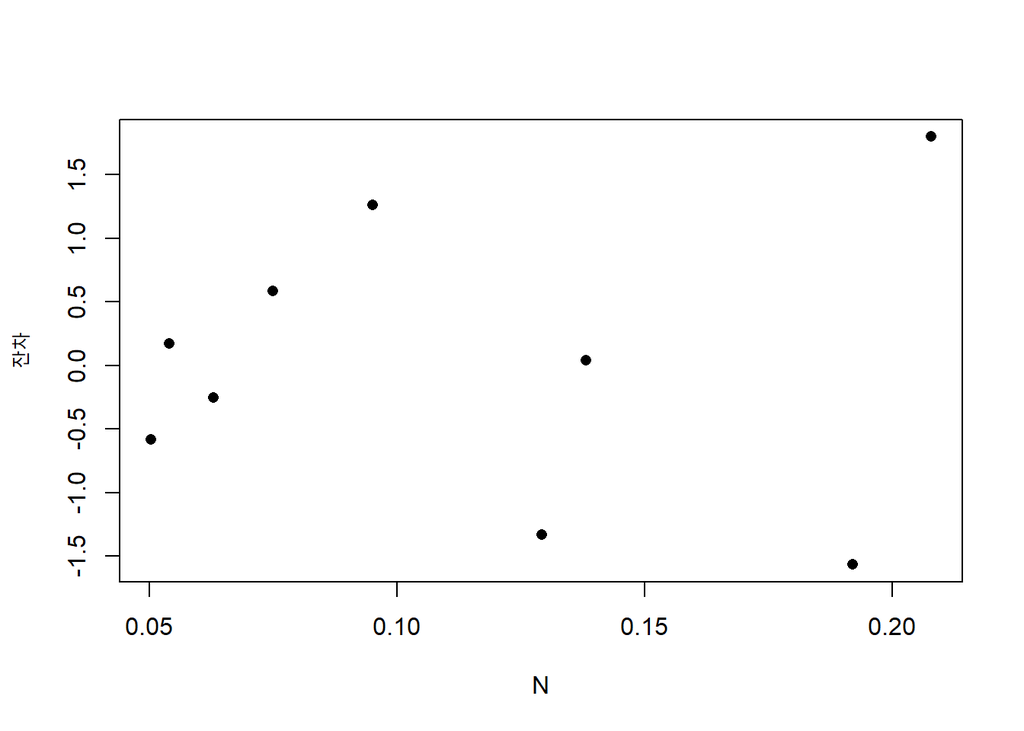

```r
plot(flight$N, rstandard(fit5), xlab = "N", ylab = "잔차", pch = 16)
```

- 원모형 $y_i = \beta_0 + \beta_1n_i + \epsilon_i$ : $n_i$의 증가에 따라 잔차의 변화폭이 증가함 -> 이분산성 o, 등분산성 x

  이를 경험에 근거하여 포아송 변수에 대해 제곱근 변환을 수행하면

```r
fit6 = lm(sqrt(Y) ~ N, data = flight)
summary(fit6)
```

```
##
## Call:
## lm(formula = sqrt(Y) ~ N, data = flight)
##
## Residuals:
##     Min      1Q  Median      3Q     Max
## -0.9690 -0.7655  0.1906  0.5874  1.0211
##
## Coefficients:
##             Estimate Std. Error t value Pr(>|t|)
## (Intercept)   1.1692     0.5783   2.022   0.0829 .
## N            11.8564     4.6382   2.556   0.0378 *
## ---
## Signif. codes:  0 '***' 0.001 '**' 0.01 '*' 0.05 '.' 0.1 ' ' 1
##
## Residual standard error: 0.7733 on 7 degrees of freedom
## Multiple R-squared:  0.4828, Adjusted R-squared:  0.4089
## F-statistic: 6.535 on 1 and 7 DF,  p-value: 0.03776
```

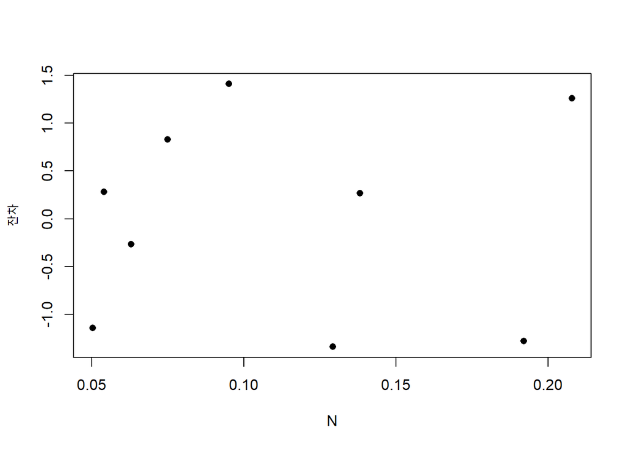

```r
plot(flight$N, rstandard(fit6), xlab = "N", ylab = "잔차", pch = 16)
```

- 변환모형 $\sqrt(y_i) = \beta_0' + \beta_1'n_i + \epsilon_i$ : $n_i$와 더불어 변환하는 양상을 보이지 않음 -> 등분산성 o, but 통계적으로 설명력($R^2$)이 떨어지므로 다른 요인을 모형에 고려할 필요가 있음

### 6.7 가중최소제곱법

- 가중최소제곱(WLS) : 회귀모수들에 오차항의 분산에 반비례하는 가중값을 준 가중오차제곱합을 최소화하여 추정하는 것

  -> $\sum(y_i - \beta_0 - \beta_1x_i)^2$

### 6.8 데이터에 대한 로그변환

- 로그변환 : 원데이터를 그대로 사용하지 않고 로그변환을 취한 후에 분석을 시도하는 것
  - 분석 대상변수가 평균에 비해 큰 표준편차를 가진 경우 필요
  - 특징 : 변이를 무디게 함, 비대칭성을 줄임, 이분산성 제거
  - 문제점 : 0이나 음수값에 대해서는 적용이 안되어 다른 변환 방법이 필요함
- 로그변환에 대한 예제

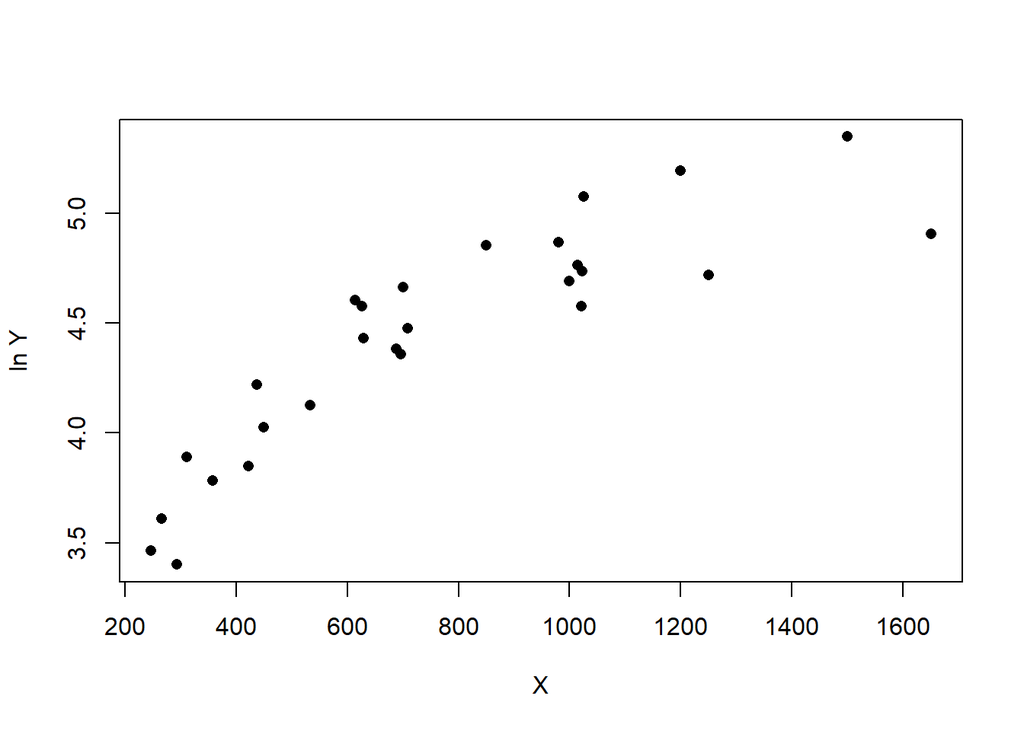

```r
plot(factory$X, log(factory$Y), xlab = "X", ylab = "ln Y", pch = 16)
```

```r
fit7 = lm(log(Y) ~ X, data = factory)
summary(fit7)
```

```
##
## Call:
## lm(formula = log(Y) ~ X, data = factory)
##
## Residuals:
##      Min       1Q   Median       3Q      Max
## -0.59648 -0.16578  0.00244  0.17481  0.34964
##
## Coefficients:
##              Estimate Std. Error t value Pr(>|t|)
## (Intercept) 3.5150232  0.1110670  31.648  < 2e-16 ***
## X           0.0012041  0.0001316   9.153 1.85e-09 ***
## ---
## Signif. codes:  0 '***' 0.001 '**' 0.01 '*' 0.05 '.' 0.1 ' ' 1
##
## Residual standard error: 0.2524 on 25 degrees of freedom
## Multiple R-squared:  0.7702, Adjusted R-squared:  0.761
## F-statistic: 83.77 on 1 and 25 DF,  p-value: 1.855e-09
```

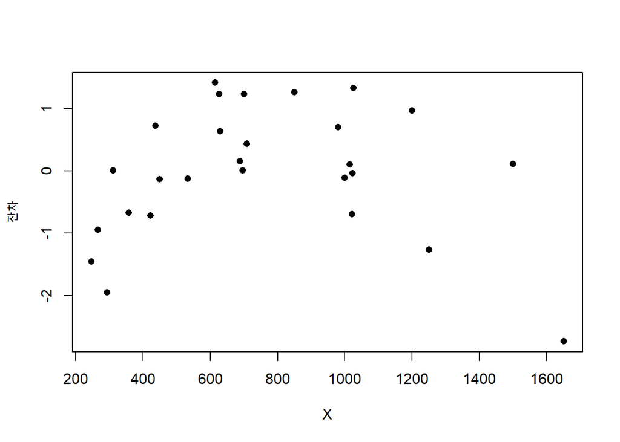

```r
plot(factory$X, rstandard(fit7), xlab = "X", ylab = "잔차", pch = 16)
```

- X에 대한 ln Y의 회귀로부터 얻은 표준화잔차플롯을 보면 이분산성은 제거되었으나 잔차들이 2차곡선 모양을 보여 명백한 비선형성을 보인다.
- 이와 같은 경우에는 $ln\,y_i = \beta_0 + \beta_1x_i + \beta_2x_i^2 + \epsilon_i$와 같은 모형이 더 적절할 수 있으므로 이 식을 적용해보겠다.

```r
X_2 = factory$X * factory$X
fit8 = lm(log(Y) ~ X + X_2, data = factory)
summary(fit8)
```

```
##
## Call:
## lm(formula = log(Y) ~ X + X_2, data = factory)
##
## Residuals:
##      Min       1Q   Median       3Q      Max
## -0.30589 -0.11705 -0.02707  0.17593  0.30657
##
## Coefficients:
##               Estimate Std. Error t value Pr(>|t|)
## (Intercept)  2.852e+00  1.566e-01  18.205 1.50e-15 ***
## X            3.113e-03  3.989e-04   7.803 4.90e-08 ***
## X_2         -1.102e-06  2.238e-07  -4.925 5.03e-05 ***
## ---
## Signif. codes:  0 '***' 0.001 '**' 0.01 '*' 0.05 '.' 0.1 ' ' 1
##
## Residual standard error: 0.1817 on 24 degrees of freedom
## Multiple R-squared:  0.8857, Adjusted R-squared:  0.8762
## F-statistic: 92.98 on 2 and 24 DF,  p-value: 4.976e-12
```

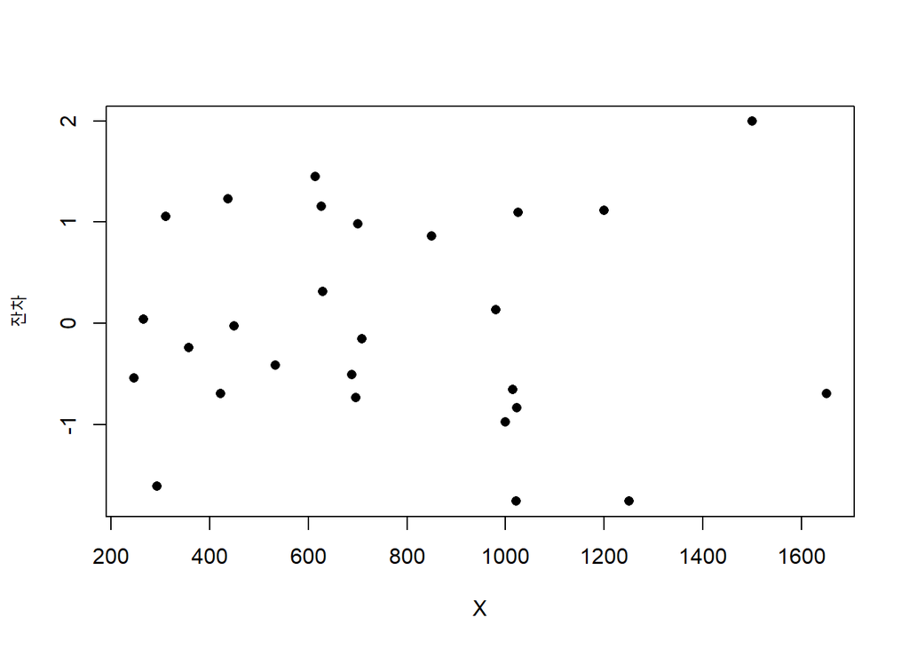

```r
plot(factory$X, rstandard(fit8), xlab = "X", ylab = "잔차", pch = 16)
```

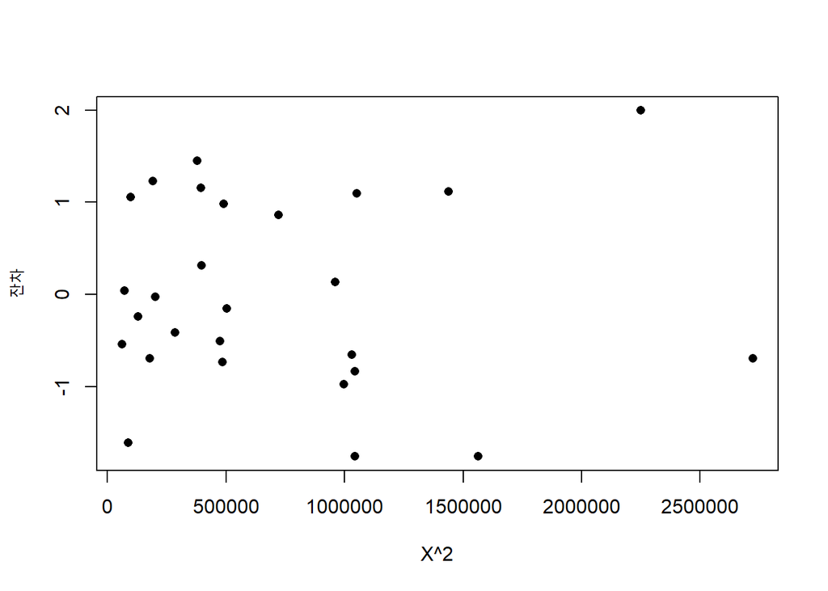

```r
plot(X_2, rstandard(fit8), xlab = "X^2", ylab = "잔차", pch = 16)
```

- 이차항을 포함하는 모형에서의 표준화잔차플롯에서는 이분산성이나 비선형성을 보이지 않아 좋은 모형이라고 할 수 있다.

### 연습문제 6.4

#### 바람 냉각의 요인 : 표 6.18은 정지 대기에서 잰 실제 온도(T)와 풍속(V)하에서 바람으로 인해 일어나는 냉각 효과가 반영된 체감 온도(W)를 나타내고 있다. 바람이 없는 상태(zero-wind condition)는 사람이 정지 대기에서 걸을 때 느끼는 냉기의 비율로 취해진다. 원래는 국립기상국에서 출가난 데이터이나, 여기에서는 Boston의 과학 박물관에서 출간한 것을 재편집하여 사용하고자 한다. 온도는 모두 화씨로 잰 것이며, 풍속은 시간당 마일(mph) 단위로 측정하였다.

1. 표 6.18의 데이터는 회귀분석 프로그램에서 직접 사용하기에는 적절하지 않은 형태로 되어 있다. 따라서 변수 W, T, V에 대응하는 세 개의 열을 가지는 다른 데이터 표를 작성할 필요가 있다. 이 표는 이 책의 웹사이트에서 찾을 수 있다.

```r
setwd("C:/Users/X-Note/Desktop")
wind = read.table("wind.txt", header = T)
head(wind)
```

```
##    W  V  T
## 1 48  5 50
## 2 40 10 50
## 3 35 15 50
## 4 32 20 50
## 5 30 25 50
## 6 28 30 50
```

2. 변수 W, T, V 사이의 선형회귀모형을 적합하여라. 잔차들의 패턴을 검토하여 선형모형의 적절성 여부를 조사하여라.
- 문제에서 실제온도(T)와 풍속(V) 하에서 바람으로 인해 일어나는 냉각효과가 반영된 체감온도(W)라고 하였기에 원인을 온도와 풍속, 결과를 체감온도로 두고 선형회귀모형을 적합해보겠다.

```r
lm_wind = lm(W ~ T + V, data = wind)
summary(lm_wind)
```

```
##
## Call:
## lm(formula = W ~ T + V, data = wind)
##
## Residuals:
##     Min      1Q  Median      3Q     Max
## -11.560  -6.106  -1.791   4.336  33.704
##
## Coefficients:
##             Estimate Std. Error t value Pr(>|t|)
## (Intercept) -9.05664    1.71960  -5.267  6.4e-07 ***
## T            1.41867    0.02301  61.661  < 2e-16 ***
## V           -1.10545    0.05530 -19.989  < 2e-16 ***
## ---
## Signif. codes:  0 '***' 0.001 '**' 0.01 '*' 0.05 '.' 0.1 ' ' 1
##
## Residual standard error: 8.7 on 117 degrees of freedom
## Multiple R-squared:  0.9729, Adjusted R-squared:  0.9724
## F-statistic:  2101 on 2 and 117 DF,  p-value: < 2.2e-16
```

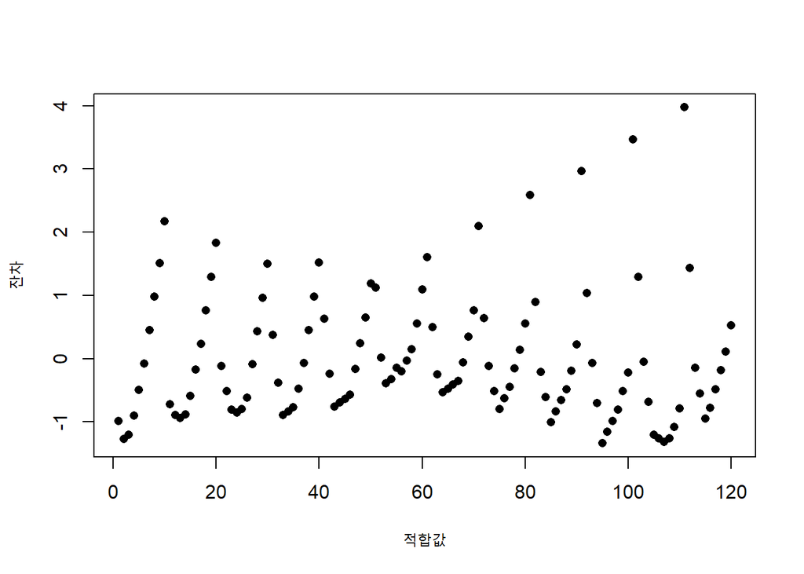

```r
plot(rstandard(lm_wind), xlab = "적합값", ylab = "잔차", pch = 16)
```

- 회귀 적합 결과, 모든 회귀계수에 대하여 p-value가 0에 수렴하는 매우 작은 수이므로 유의한 회귀계수라고 할 수 있다.
- 표준화잔차 대 적합값의 플롯을 그려보니 적합값이 커짐에 따라 좁은 깔때기 모양으로 모였다가 특정 기점을 기준으로 넓은 깔때기 모양으로 퍼지는 형태가 나왔다. 이를 통해 현재 적합한 lm_wind에서는 이분산성이 나타나며 등분산성을 만족하지 않음을 알 수 있다.
3. T의 효과에 대하여 W를 조정한 후(즉, T를 고정시킨 상태에서) W와 V 사이의 관계를 살펴보아라. 이들 두 변수 사이의 관계가 선형적인가?

```r
lm_wind_v = lm(W ~ T + sqrt(V), data = wind)
summary(lm_wind_v)
```

```
##
## Call:
## lm(formula = W ~ T + sqrt(V), data = wind)
##
## Residuals:
##     Min      1Q  Median      3Q     Max
## -14.206  -4.436  -1.226   3.588  27.848
##
## Coefficients:
##              Estimate Std. Error t value Pr(>|t|)
## (Intercept)  15.91744    2.31573   6.874 3.25e-10 ***
## T             1.41867    0.01921  73.853  < 2e-16 ***
## sqrt(V)     -11.02178    0.44121 -24.981  < 2e-16 ***
## ---
## Signif. codes:  0 '***' 0.001 '**' 0.01 '*' 0.05 '.' 0.1 ' ' 1
##
## Residual standard error: 7.264 on 117 degrees of freedom
## Multiple R-squared:  0.9811, Adjusted R-squared:  0.9808
## F-statistic:  3039 on 2 and 117 DF,  p-value: < 2.2e-16
```

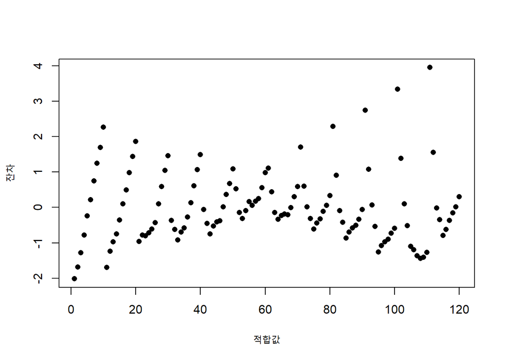

```r
plot(rstandard(lm_wind_v), xlab = "적합값", ylab = "잔차", pch = 16)
```

- 회귀 적합 결과, 모든 회귀계수에 대하여 p-value가 0에 수렴하는 매우 작은 수이므로 유의한 회귀계수라고 할 수 있다. 결정계수 값은 0.9811로 매우 높은 수치이다.
- 포아송 분포 변환으로 변수를 변환해보았는데, 원 데이터의 표준화잔차와 마찬가지로 특정한 깔때기 형태를 띠어 이분산적이라고 할 수 있다.
- 위의 결과를 통해 통계적 수치적으로는 유의하나 등분산성을 만족하지 않으므로 선형적이라고 할 수 없다.
4. V의 효과에 대하여 W를 조정한 후 W와 T 사이의 관계를 살펴보아라. 이들 두 변수 사이의 관계가 선형적인가?

```r
lm_wind_t = lm(W ~ V + sqrt(T), data = wind)
summary(lm_wind_t)
```

```
##
## Call:
## lm(formula = W ~ V + sqrt(T), data = wind)
##
## Residuals:
##      Min       1Q   Median       3Q      Max
## -15.0327  -8.0237   0.8163   6.0263  24.6032
##
## Coefficients:
##              Estimate Std. Error t value Pr(>|t|)
## (Intercept) -25.81533    3.47099  -7.437 5.94e-10 ***
## V            -0.75758    0.08426  -8.990 1.60e-12 ***
## sqrt(T)       9.66875    0.51684  18.707  < 2e-16 ***
## ---
## Signif. codes:  0 '***' 0.001 '**' 0.01 '*' 0.05 '.' 0.1 ' ' 1
##
## Residual standard error: 9.374 on 57 degrees of freedom
##   (60 observations deleted due to missingness)
## Multiple R-squared:  0.8831, Adjusted R-squared:  0.879
## F-statistic: 215.4 on 2 and 57 DF,  p-value: < 2.2e-16
```

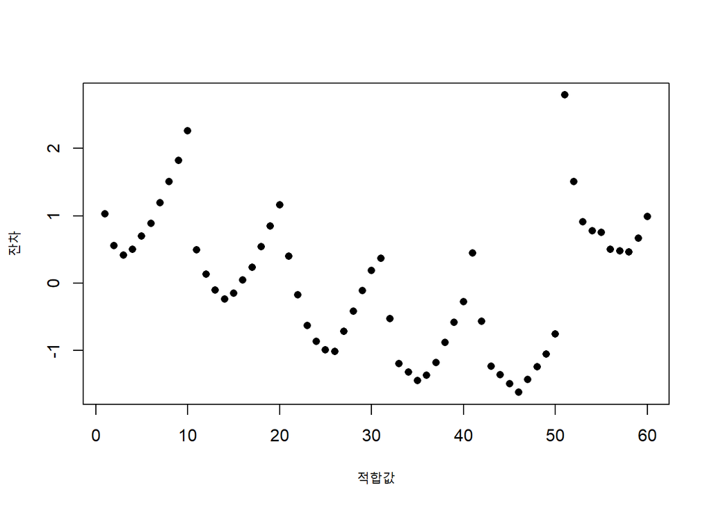

```r
plot(rstandard(lm_wind_t), xlab = "적합값", ylab = "잔차", pch = 16)
```

- 회귀 적합 결과, 모든 회귀계수에 대하여 p-value가 0에 수렴하는 매우 작은 수이므로 유의한 회귀계수라고 할 수 있다. 결정계수 값은 0.8831로 (c)의 모형보다는 다소 떨어진다.
- (c)번과 마찬가지로 포아송 분포 변환으로 변수를 변환하였는데 원 데이터의 표준화잔차의 형태와는 다르지만 이차곡선이 일정한 주기 내에서 반복되는 형태를 띤다.
- 위의 결과를 통해 통계적 수치적으로는 유의하고 이분산성을 보이지는 않지만 잔차들이 이차곡선 모양을 보이므로 선형적이라고 할 수 없다.
5. 다음 모형을 적합하여라.
   $$W = \beta_0 + \beta_1T + \beta_2V + \beta_3\sqrt(V) + \epsilon$$
   - (6.18) 이 모형의 적합이 적절하게 나타나고 있는가? W 값은 국립기상국에서 다음 공식(반올림에 따른 오차는 제외)을 사용하여 얻은 것이다.
   $$W = 0.0817(3.71\sqrt(V) + 5.81 - 0.25V)(T - 91.4) + 91.4$$
   - (6.19) 이 공식의 정확도를 주어진 데이터를 통해 검토하여라.

```r
lm_wind_v2 = lm(W ~ T + V + sqrt(V), data = wind)
summary(lm_wind_v2)
```

```
##
## Call:
## lm(formula = W ~ T + V + sqrt(V), data = wind)
##
## Residuals:
##     Min      1Q  Median      3Q     Max
## -20.565  -2.873   0.044   3.154  21.489
##
## Coefficients:
##              Estimate Std. Error t value Pr(>|t|)
## (Intercept)  48.90935    5.88953   8.304 2.11e-13 ***
## T             1.41867    0.01687  84.076  < 2e-16 ***
## V             1.65055    0.27651   5.969 2.66e-08 ***
## sqrt(V)     -26.62313    2.64225 -10.076  < 2e-16 ***
## ---
## Signif. codes:  0 '***' 0.001 '**' 0.01 '*' 0.05 '.' 0.1 ' ' 1
##
## Residual standard error: 6.381 on 116 degrees of freedom
## Multiple R-squared:  0.9856, Adjusted R-squared:  0.9852
## F-statistic:  2638 on 3 and 116 DF,  p-value: < 2.2e-16
```

- 회귀 적합 결과, 모든 회귀계수에 대하여 p-value가 0에 수렴하는 매우 작은 수이므로 유의한 회귀계수라고 할 수 있다. 결정계수 값은 0.9856으로 매우 높은 수치이다. 이 적합을 통해 나온 회귀 적합식은 다음과 같다.
  $$W = 48.91 + 1.42T + 1.65V - 26.62\sqrt(V)$$
6. 식 (6.18), (6.19)에 있는 모형들보다 더 좋은 모형을 제안할 수 있는가?
- 포아송 변환이 아닌 다양한 다른 변수변환법을 활용한다면 이보다 더 좋은 모형이 나올 수도 있을 것이다.